# 6 Lactancia vs infecciones

Autor/a

Mario Camacho

Fecha de publicación

02 mayo 2026

## 6.1 Relación entre la prevalencia de leche materna y las infecciones

### 6.1.1 Sin diferenciar entre tipo de infecciones (respiratorias o digestivas)

La variable ‘Tipo de lactancia’ es una variable categórica de tres niveles y la variable ‘Infecciones’ es de dos niveles. No tenemos en cuenta los casos sin información del tipo de lactancia ya que no es posible imputar estos valores.

**Métodos**

Se pretende evaluar si el tipo de lactancia está relacionado con la presencia de infecciones. La asociación entre el tipo de lactancia y la presencia de infecciones se midió mediante el test de la chi-cuadrado de Pearson, adecuado para variables categóricas. Se verifican los supuestos del test a partir de las frecuencias esperadas y, en caso de no cumplirse, se empleará el test exacto de Fisher. También se estima el tamaño del efecto mediante la V de Cramer, con el objetivo de cuantificar la magnitud de la asociación independientemente del tamaño muestral.

**Resultados**

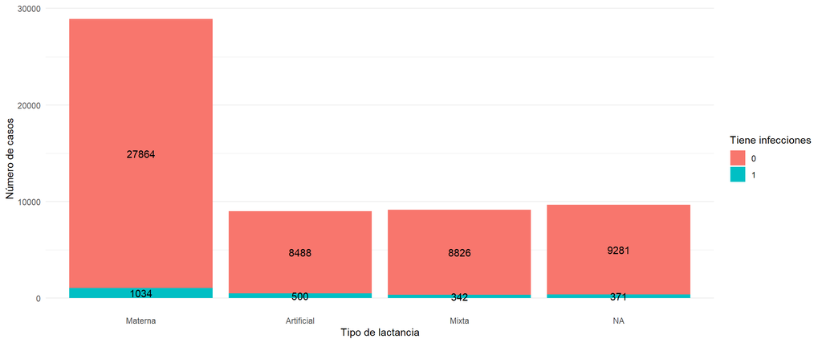

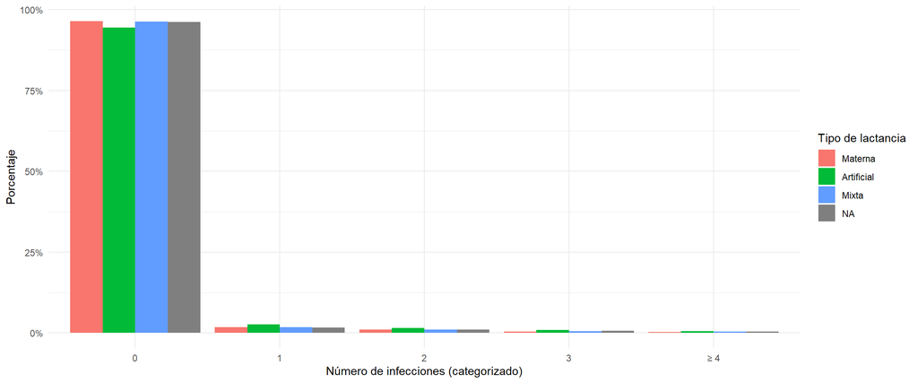

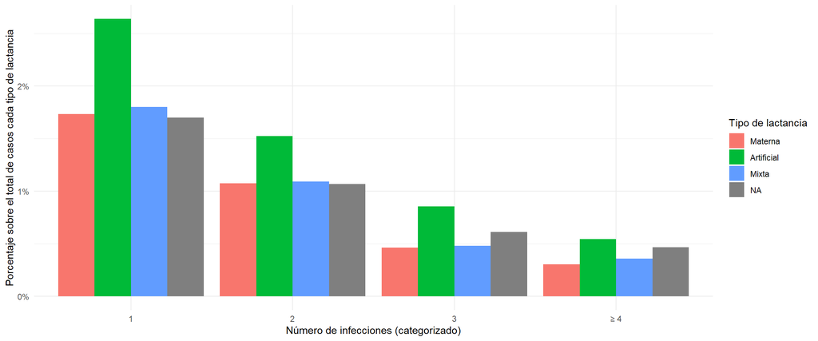

```
                   Infecciones
 Tipo de lactancia           0     1
           Materna       0.964 0.036
        Artificial       0.944 0.056
             Mixta       0.963 0.037
              <NA>       0.962 0.038

    Pearson's Chi-squared test

data:  tab
X-squared = 72.516, df = 2, p-value < 2.2e-16


Interpretación p-valor: existe evidencia de asociación

V de Cramer = 0.039
Interpretación: asociación insignificante o nula
```

El test mostró evidencia de asociación estadística (p-valor < 0.001). Existe evidencia estadística de asociación entre el tipo de lactancia y la presencia de infecciones. La interpretación final debe basarse en el tamaño del efecto, ya que en muestras grandes la significación estadística puede sobreestimar la relevancia clínica del hallazgo. (**Ref.**) El tamaños del efecto muestra que la asociación insignificante (V de Cramer: 0.039).

**Métodos**

Se pretende evaluar si el tipo de lactancia está relacionado con el número de infecciones, es decir, si la distribución del número de infecciones cambia según el tipo de lactancia. En caso de encontrar diferencias en las distribuciones se realizarán comparaciones post hoc entre pares de grupos. Dado que la variable número de infecciones es de naturaleza de conteo, no se asume a priori la normalidad de la variable y su distribución se describe a través de mediana y rango intercuartílico. Además, a los valores superiores a 5 se les asigna el 5 en la base de datos.

Para evaluar la asociación de la variable de conteo número de infecciones con la variable categórica tipo de lactancia, se plantea un modelo de regresión de Poisson. A partir de este modelo se estiman los Incidence Rate Ratios (IRR) y sus intervalos de confianza al 95 %. Previamente, se comprueba el supuesto de equidispersión, es decir, que la media y la varianza de la variable de conteo sean aproximadamente iguales. En caso de detectarse sobredispersión, se emplea un modelo de regresión binomial negativa y se calculan sus IRR e intervalos de confianza al 95 %. De forma únicamente exploratoria, se emplea el test no paramétrico de Kruskal–Wallis para comparar la distribución del número de infecciones entre los grupos de lactancia.

**Resultados**

Distribución de niños con y sin infecciones por año. (Más información en la pestaña ‘Análisis exploratorio’)

```
# A tibble: 2 × 6
  tiene_infecciones `2018` `2019` `2020` `2021` `2022*`
  <fct>              <dbl>  <dbl>  <dbl>  <dbl>   <dbl>
1 0                  0.946  0.956  0.983  0.953   0.966
2 1                  0.054  0.044  0.017  0.047   0.034
```

Distribución del número de infecciones (solo aquellos casos con infecciones).

```
# A tibble: 1 × 11
    `1`   `2`   `3`   `4`   `5`   `6`   `7`   `8`   `9`  `11`  `12`
  <dbl> <dbl> <dbl> <dbl> <dbl> <dbl> <dbl> <dbl> <dbl> <dbl> <dbl>
1 0.475  0.29  0.14 0.049 0.024 0.012 0.004 0.003     0     0 0.003
```

Distribución del número de infecciones (solo aquellos casos con infecciones) cuando a los valores mayores a 5 se les asignada un 5.

```
# A tibble: 1 × 5
    `1`   `2`   `3`   `4`   `5`
  <dbl> <dbl> <dbl> <dbl> <dbl>
1 0.475  0.29  0.14 0.049 0.046
```

Mediana e IQR del número de infecciones por tipo de lactancia, filtrado únicamente por aquellos casos donde el número de infecciones es mayor a 0 para minimizar la distorsión, ya que más del 90 % de los casos no tienen registros de hospitalizaicón y, por tanto, tienen cero infecciones.

Solo se incluyen sujetos con n_infecciones > 0

| **Characteristic** | **Overall** N = 1,876<sup>1</sup> | **Materna** N = 1,034<sup>1</sup> | **Artificial** N = 500<sup>1</sup> | **Mixta** N = 342<sup>1</sup> | **p-value**<sup>2</sup> |
| --- | --- | --- | --- | --- | --- |
| n_infecciones | 2.00 (1.00-2.00) | 2.00 (1.00-2.00) | 2.00 (1.00-3.00) | 2.00 (1.00-2.00) |  |

<sup>1</sup> Median (Q1-Q3)  
<sup>2</sup> NA

La asociación entre el tipo de lactancia (variable categórica) y el número de infecciones (variable cuantitativa discreta de conteo) se estudió con un modelo de regresión de Poisson.

```
Varianza del número de infecciones: 0.19
Media del número de infecciones: 0.08
Ratio varianza/media = 2.47
Posible sobredispersión
Dispersión en los residuos del modelo: 2.43
Debido a la sobredispersión detectada y que preveíamos, la relación se mide con un modelo de binomial negativa.
```

Se observó sobredispersión en la variable número de infecciones (varianza = 0.19, media = 0.08; ratio varianza/media = 2.47), lo que indica desviación del supuesto de equidispersión de la distribución de Poisson (la sobredispersión es una característica común en datos de conteo reales (**Ref.**)). Por ello, se consideró como alternativa un modelo de regresión binomial negativa, más flexible ante la presencia de sobredispersión. (**Ref.**) De forma complementaria y con carácter exploratorio, se utilizó el test no paramétrico de Kruskal–Wallis para comparar la distribución del número de infecciones entre los grupos de lactancia.

```
Call:  glm.nb(formula = n_infecciones ~ tipo_lactancia, data = data,
    init.theta = 0.03746600401, link = log)

Coefficients:
             (Intercept)  tipo_lactanciaArtificial       tipo_lactanciaMixta
                -2.71041                   0.47056                   0.05773

Degrees of Freedom: 47053 Total (i.e. Null);  47051 Residual
  (9652 observations deleted due to missingness)
Null Deviance:      6060
Residual Deviance: 6017     AIC: 20750
```

**AdvertenciaConclusiones estadísticas**

El intercepto del modelo representa el número medio esperado de infecciones en el grupo de referencia del tipo de lactancia. La media estimada fue de 0.067 infecciones por individuo durante el pe riodo de seguimiento (IC 95 %: 0.062 – 0.072), asumiendo un periodo de seguimiento homogéneo entre los individuos **(estoy suponiendo que es un año)**.

El efecto de cada tipo de lactancia interpretó a través de los IRR respecto al grupo de referenca en lugar de analizar directamente los coeficientes del modelo. Los bebés con lactancia artificial presentaron un número medio esperado de infecciones significativamente superior al observado en el grupo de lactancia materna (IRR = 1.601; IC 95 %: 1.386 – 1.852). Esto indica un incremento estimado del 60.1 % (IC 95 %: 38.6 % - 85.2 %) en la media esperada de infecciones. Dado que el intervalo de confianza del IRR no incluye el valor nulo de 1, la asociación resulta estadísticamente significativa. En cambio, la lactancia mixta no mostró diferencias estadísticamente significativas respecto a la lactancia materna (IRR = 1.059; IC 95 %: 0.912 – 1.232), aunque la estimación puntual sugiere un incremento del 5.9 % en la media esperada de infecciones.

**Formato friendly**

El intercepto del modelo representa el número medio esperado de infecciones en el grupo de referencia, es decir, los bebés con lactancia materna. En este grupo se estimó una media de 0.067 infecciones por niño durante el periodo de seguimiento (IC del 95 %: 0.062–0.072), asumiendo que todos los participantes tuvieron aproximadamente el mismo tiempo de seguimiento (en este caso, un año).

Para comparar los distintos tipos de lactancia se utilizaron las razones de tasas de incidencia (IRR), tomando como referencia la lactancia materna.

Los bebés con lactancia artificial presentaron un número esperado de infecciones significativamente mayor que los alimentados con lactancia materna (IRR = 1.601; IC del 95 %: 1.386–1.852). Esto significa que, de media, se espera un 60.1% más de infecciones en este grupo, con un incremento compatible con los datos de entre el 38.6% y el 85.2%. Como el intervalo de confianza no incluye el valor 1, esta diferencia es estadísticamente significativa.

En cambio, los bebés con lactancia mixta no mostraron diferencias estadísticamente significativas respecto a los alimentados con lactancia materna (IRR = 1.059; IC del 95 %: 0.912–1.232). Aunque la estimación puntual sugiere un 5.9% más de infecciones, los datos son compatibles tanto con una ligera reducción como con un aumento moderado del riesgo, por lo que no puede concluirse que exista una diferencia entre ambos grupos.

```
                           IRR IC 2.5 IC 97.5 significativo
(Intercept)              0.067  0.062   0.072             1
tipo_lactanciaArtificial 1.601  1.386   1.852             1
tipo_lactanciaMixta      1.059  0.912   1.232             0
```

```
tipo_lactanciaArtificial
IRR:  1.601 (significativo)
IRR > 1 -> efecto nocivo o de riesgo (comparado con latancia materna )
1.386 - 1 = 0.386 ( 38.6 % más en el mejor caso)
1.852 - 1 = 0.852 ( 85.2 % más en el peor caso)
Aumento del 39 al 85 % en el número medio esperado de infecciones.


tipo_lactanciaMixta
IRR:  1.059 (no significativo)
IRR > 1 -> efecto nocivo o de riesgo (comparado con latancia materna )
0.912 - 1 = -0.088 ( -8.8 % más en el mejor caso)
1.232 - 1 = 0.232 ( 23.2 % más en el peor caso)
Aumento del -9 al 23 % en el número medio esperado de infecciones.
```

De forma exploratoria, se usa el test no paramétrico de Kruskal–Wallis para comparar el número de infecciones entre los tipos de lactancia sin asumir normalidad en la variable respuesta número de infecciones. Los resultados mostraron diferencias estadísticamente significativas entre los grupos (chi-cuadrado = 72.84, gl = 2, p < 0.001), lo que indica que al menos uno de los tipos de lactancia presenta una distribución del número de infecciones diferente de los demás. El tamaño del efecto estimado (epsilon^2 = 0.001) sugiere que las diferencias entre grupos, aunque estadísticamente significativas, tiene una relevancia clínica ínfima.

```
    Kruskal-Wallis rank sum test

data:  n_infecciones by tipo_lactancia
Kruskal-Wallis chi-squared = 72.842, df = 2, p-value < 2.2e-16
```

```
Existen diferencias estadísticamente significativas en el número de infecciones entre los tipos de lactancia (p = 1.52e-16 ).
Al menos un grupo difiere del resto.
```

```
Tamaño de efecto (epsilon^2): 0.001 ( efecto trivial desde el punto de vista práctico)
```

### 6.1.2 Diferenciando entre tipo de infecciones (respiratorias o digestivas)

**ImportanteWIP**